# Hypothesis Testing

```python
import pandas as pd
import numpy as np
import matplotlib.pyplot as plt
import re
```

```python
from scipy.stats import stats
from scipy.stats import t
from scipy.stats import ttest_ind
from scipy.stats import ttest_rel
from scipy.stats import ansari
from scipy.stats import shapiro
from scipy.stats import wilcoxon
```

## T-test: Hypothesis Testing

```python
tips = pd.read_csv("../data_raw/ht_tips.csv")
```

```python
tips.head()
```

|  | total_bill | tip | sex | smoker | day | time | size |
| --- | --- | --- | --- | --- | --- | --- | --- |
| 0 | 16.99 | 1.01 | Female | No | Sun | Dinner | 2 |
| 1 | 10.34 | 1.66 | Male | No | Sun | Dinner | 3 |
| 2 | 21.01 | 3.50 | Male | No | Sun | Dinner | 3 |
| 3 | 23.68 | 3.31 | Male | No | Sun | Dinner | 2 |
| 4 | 24.59 | 3.61 | Female | No | Sun | Dinner | 4 |

```python
tips.shape
```

```
(244, 7)
```

```python
tips.mean (axis=0, numeric_only=True)
```

```
total_bill    19.785943
tip            2.998279
size           2.569672
dtype: float64
```

```python
tips["sex"].describe()
```

```
count      244
unique       2
top       Male
freq       157
Name: sex, dtype: object
```

```python
tips["day"].describe()
```

```
count     244
unique      4
top       Sat
freq       87
Name: day, dtype: object
```

```python
stats.ttest_1samp?
```

```python
# two-sided test for the null hypothesis that the expected value
# (mean) of a sample of independent observations `a` is equal to the given
# population mean, `popmean`
stats.ttest_1samp (tips["tip"], popmean = 2.5)
```

```
Ttest_1sampResult(statistic=5.625287009994555, pvalue=5.07998845968649e-08)
```

## Examine `t`-statistic and its probability distribution

```python
t.rvs?
```

```python
# df: degrees of freedom
df = tips.shape[0]-1
df
```

```
243
```

```python
# draw a sample of size=3000 from t-distribution
# with df degrees of freedom
r = t.rvs(df=df, size = 3000)
```

```python
# compute the meand and standard deviation
# of the random sample from t-distribution
r_mean = r.mean()
r_sd = r.std()
```

```python
tipTTest = stats.ttest_1samp (tips["tip"], popmean = 2.5)
tipTTest.statistic
```

```
5.625287009994555
```

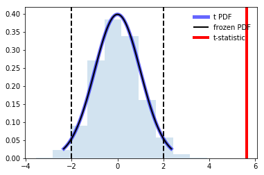

```python
fig, ax = plt.subplots(1, 1)
x = np.linspace(t.ppf(0.01, df), t.ppf(0.99, df), 100)
ax.plot(x, t.pdf(x, df),'b-', lw=5, alpha=0.6, label='t PDF')
rv = t(df)
ax.plot(x, rv.pdf(x), 'k-', lw=2, label='frozen PDF')
ax.hist(r, normed=True, histtype='stepfilled', alpha=0.2)
plt.axvline(x=tipTTest.statistic, color='r',
            linestyle='solid', lw=4, label='t-statistic')
plt.axvline(x=-2*r_sd, color='k', linestyle='--', lw=2)
plt.axvline(x=2*r_sd, color='k', linestyle='--', lw=2)
ax.legend(loc='best', frameon=False)
plt.show()
```

```python
plt.axvline?
```

## One Sample One-Sided `t`-Test

```python
# alpha = 0.5: 95% confidence interval
def one_tailed_t_test(data, mu, alternative="less than", alpha=0.05):
    # one-tailed, less than 130

    results = stats.ttest_1samp(data, mu)
    print ("t = {0:5.4f}  df = {1}  p-value = {2:10.9f}".
           format(results[0], str(data.shape[0]-1), results[1]))

    if re.search("less than", alternative):
        if (results[0] < 0) & (results[1]/2 < alpha):
            print ("reject null hypothesis, mean is less than {}".format(mu))
        else:
            print ("fail to reject null hypothesis, mean is greater than {}".format(mu))
            print ("sample estimate: \n\t mean of data: {}".format(data.mean(axis=0)))
    elif re.search ("greater", alternative):
        if (results[0] > 0) & (results[1]/2 < alpha):
            print ("reject null hypothesis, mean is greater than {}".format(mu) )
        else:
            print("fail to reject null hypothesis, mean is less than {}".format(mu))
            print ("sample estimate: \n\t mean of data: {}".format(data.mean(axis=0)))
    else:
        print ("invalid argument for alternative: {}".format(alternative))
```

```python
one_tailed_t_test(data=tips["tip"], mu=2.5,
                  alternative="less than")
```

```
t = 5.6253  df = 243  p-value = 0.000000051
fail to reject null hypothesis, mean is greater than 2.5
sample estimate:
	 mean of data: 2.9982786885245902
```

## Ansari-Bradley Test: Equality of Variances

Let's examine the variance by sex:

```python
female_tips = tips[tips["sex"]=="Female"]
female_tips.head()
```

|  | total_bill | tip | sex | smoker | day | time | size |
| --- | --- | --- | --- | --- | --- | --- | --- |
| 0 | 16.99 | 1.01 | Female | No | Sun | Dinner | 2 |
| 4 | 24.59 | 3.61 | Female | No | Sun | Dinner | 4 |
| 11 | 35.26 | 5.00 | Female | No | Sun | Dinner | 4 |
| 14 | 14.83 | 3.02 | Female | No | Sun | Dinner | 2 |
| 16 | 10.33 | 1.67 | Female | No | Sun | Dinner | 3 |

```python
male_tips = tips[tips["sex"]=="Male"]
male_tips.head()
```

|  | total_bill | tip | sex | smoker | day | time | size |
| --- | --- | --- | --- | --- | --- | --- | --- |
| 1 | 10.34 | 1.66 | Male | No | Sun | Dinner | 3 |
| 2 | 21.01 | 3.50 | Male | No | Sun | Dinner | 3 |
| 3 | 23.68 | 3.31 | Male | No | Sun | Dinner | 2 |
| 5 | 25.29 | 4.71 | Male | No | Sun | Dinner | 4 |
| 6 | 8.77 | 2.00 | Male | No | Sun | Dinner | 2 |

```python
female_tip_var = female_tips["tip"].var(axis=0)
female_tip_var
```

```
1.3444275060144353
```

```python
male_tip_var = male_tips["tip"].var(axis=0)
male_tip_var
```

```
2.2174242119875878
```

```python
female_tips = tips[tips["sex"]=="Female"]
male_tips = tips[tips["sex"]=="Male"]
print ("Female Tip Variance: {0:4.3}".format(female_tips["tip"].var(axis=0)))
print ("Male Tip Variance: {0:4.3f}".format(male_tips["tip"].var(axis=0)))
```

```
Female Tip Variance: 1.34
Male Tip Variance: 2.217
```

- Check the assumptions for applying the Ansari-Bradley Test:
  - Test for normality of `tip` distributions for each sex
  - Use Shapiro-Wilk test for normality:
    - If the sample is *not* normally distributed (i.e., the Null Hypothesis should be rejected because $p$-value < 0.05) then a *non-parametric* test, such as Ansari-Bradley Test, should be applied

```python
shapiro(female_tips["tip"])
```

```
(0.9567776918411255, 0.005448382347822189)
```

```python
shapiro(male_tips["tip"])
```

```
(0.8758689165115356, 3.708431339788376e-10)
```

```python
ansari(female_tips["tip"], male_tips["tip"])
```

```
AnsariResult(statistic=5582.5, pvalue=0.3760472514100246)
```

Results summary:

- $𝒑$-value > 0.05: fail to reject the null hypothesis
- According to this test, the results were not significant;
- Conclusion: the variances are equal

## Two-Sample T-Test: Equality of Means

```python
t, p = ttest_ind(female_tips["tip"], male_tips["tip"],
                 equal_var=True)
print("ttest_ind: t = %g p = %g" % (t, p))
```

```
ttest_ind: t = -1.38786 p = 0.166456
```

## Paired Samples T-Test

- The paired sample t-test is also called *dependent sample t-test*.
- It’s a univariate test that tests for a significant difference between two *related* variables:
  - An example of this is if you where to collect the blood pressure for an individual *before* and *after* some treatment, condition, or time point.

The **hypothesis** being test is:

> *Null hypothesis (H0)*: The mean difference between sample 1 and sample 2 is equal to 0.

> *Alternative hypothesis (HA)*: The mean difference between sample 1 and sample 2 is not equal to 0.

> If the $p$-value is less than what is tested at, most commonly 0.05, one can reject the null hypothesis.

### Paired Sample t-test Assumptions

- The dependent variable (DV) must be *continuous*, i.e., measured on an interval or ratio scale
- The DV should be approximately normally distributed:
  - Use Shapiro-Wilk test for normality
  - Testing for normality needs to be conducted on the *differences between the two conditions*, not the raw values of each condition itself
- The paired sample t-test is robust to this violation.
  - If there is a violation of normality, as long as it’s not in a major violation the test results can be considered valid
- The DV should not contain any significant outliers
- If any of these assumptions are violated, a different test should be used.
  - An alternative to the paired sample t-test is the *Wilcoxon signed-rank* Test.

```python
father_son = pd.read_csv("../data_raw/ht_father_son.csv")
```

```python
father_son.head()
```

|  | fheight | sheight |
| --- | --- | --- |
| 1 | 65.04851 | 59.77827 |
| 2 | 63.25094 | 63.21404 |
| 3 | 64.95532 | 63.34242 |
| 4 | 65.75250 | 62.79238 |
| 5 | 61.13723 | 64.28113 |

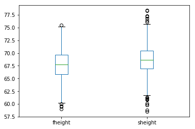

```python
import matplotlib.pyplot as plt
father_son.plot(kind='box')
plt.show()
```

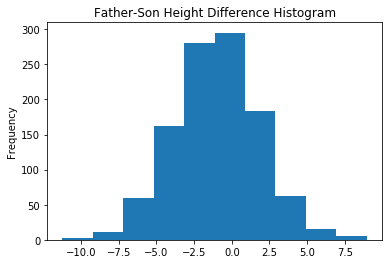

```python
# Test the difference for normality
father_son['difference'] = father_son['fheight'] - father_son['sheight']
father_son['difference'].plot(kind='hist',
            title= 'Father-Son Height Difference Histogram')
shapiro(father_son['difference'])
plt.show()
```

```python
t, p = ttest_rel(father_son["fheight"], father_son["sheight"])
print("ttest_ind: t = %g p = %g" % (t, p))
```

```
ttest_ind: t = -11.7885 p = 2.95723e-30
```

Summary Results:

- $𝒑$-value < 0.05: the null hypothesis should be rejected
- Conclusion: fathers and sons (at least for this data set) have different heights

## Wilcoxon Sign-Ranked Test

- The Wilcoxon signed-rank test is the *non-parametric* univariate test, i.e., it is an alternative to the *dependent* t-test.
- It also is called the **Wilcoxon T** test.
- This is the recommended test to use when the data violates the assumption of normality.
- It’s used to test if there is a significant difference on scores when there is a “before” and “after” condition of some treatment or intervention.
  - An example of this is if you where to collect the blood pressure for an individual before and after some treatment, condition, or time point.

The **hypothesis** being test is:

> *Null hypothesis (H0)*: The difference between the pairs follows a symmetric distribution around zero.

> *Alternative hypothesis (HA)*: The difference between the pairs does not follow a symmetric distribution around zero.

> If the $p$-value is less than what is tested at, most commonly 0.05, one can reject the null hypothesis.

### Wilcoxon Signed-Rank Test Assumptions

- The dependent variable (DV) must be continuous, i.e., measured on an *ordinal* or *continuous* scale
- The *paired* observations are randomly and independently drawn
- The paired observations come from the same population
- If any of these assumptions are violated, a different test should be used.

```python
bp = pd.read_csv("../data_raw/ht_synthetic_blood_pressure.csv")
bp.head(3)
```

|  | patient | sex | agegrp | bp_before | bp_after |
| --- | --- | --- | --- | --- | --- |
| 0 | 1 | Male | 30-45 | 143 | 153 |
| 1 | 2 | Male | 30-45 | 163 | 170 |
| 2 | 3 | Male | 30-45 | 153 | 168 |

- The Wilcoxon signed-rank test has no assumptions about the distribution of the data:
  - so there is nothing to check in that regard.
- This test works similarly to *dependent* t-test:
  - it is based on the differences between the two conditions that are being paired.
- If there is a difference of 0, these scores need to be excluded from the ranking.
- Let’s calculate this and see if there are any differences that are equal to 0.

```python
# Calculate the differences between the two conditions
bp['difference'] = bp['bp_after'] - bp['bp_before']
bp['difference'][bp['difference']==0]
```

```
41     0
74     0
103    0
115    0
Name: difference, dtype: int64
```

- Since there are differences of 0, these scores need to be excluded from the ranking process.
  - Although this is an easy process to do using Python, the test method itself will automatically exclude any 0 difference from the calculation so there is nothing more that needs to be done.

```python
# Method-1: Using the difference
wilcoxon (bp['difference'])
```

```
WilcoxonResult(statistic=2234.5, pvalue=0.0014107333565442858)
```

```python
# Method-2: Using both variables
wilcoxon (bp['bp_after'], bp['bp_before'])
```

```
WilcoxonResult(statistic=2234.5, pvalue=0.0014107333565442858)
```

Summary of test results:

  > The blood pressure before the intervention was higher (M= 156.45 ± 11.39 units) compared to the blood pressure post intervention (M= 151.36 ± 14.18 units); there was a statistically significant decrease in blood pressure (t=2,234.5, p= 0.0014).

## Paired T-Test: Parametric Comparison of two Dependent Groups

```python
UScrime = pd.read_csv("../data_raw/ht_US_crime.csv")
UScrime.head(3)
```

|  | M | So | Ed | Po1 | Po2 | LF | M.F | Pop | NW | U1 | U2 | GDP | Ineq | Prob | Time | y |
| --- | --- | --- | --- | --- | --- | --- | --- | --- | --- | --- | --- | --- | --- | --- | --- | --- |
| 1 | 151 | 1 | 91 | 58 | 56 | 510 | 950 | 33 | 301 | 108 | 41 | 394 | 261 | 0.084602 | 26.2011 | 791 |
| 2 | 143 | 0 | 113 | 103 | 95 | 583 | 1012 | 13 | 102 | 96 | 36 | 557 | 194 | 0.029599 | 25.2999 | 1635 |
| 3 | 142 | 1 | 89 | 45 | 44 | 533 | 969 | 18 | 219 | 94 | 33 | 318 | 250 | 0.083401 | 24.3006 | 578 |

```python
# Unemployment rates: younger vs. older males in Alabama
# Note differences in means and standard deviations

UScrime[['U1', 'U2']].describe()
```

|  | U1 | U2 |
| --- | --- | --- |
| count | 47.000000 | 47.000000 |
| mean | 95.468085 | 33.978723 |
| std | 18.028783 | 8.445450 |
| min | 70.000000 | 20.000000 |
| 25% | 80.500000 | 27.500000 |
| 50% | 92.000000 | 34.000000 |
| 75% | 104.000000 | 38.500000 |
| max | 142.000000 | 58.000000 |

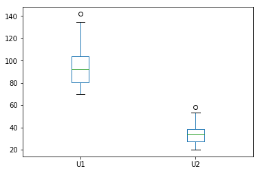

```python
UScrime[['U1', 'U2']].plot(kind='box')
plt.show()
```

```python
t, p = ttest_rel(UScrime["U1"], UScrime["U2"])
print("ttest_ind: t = %g p = %g" % (t, p))
```

```
ttest_ind: t = 32.4066 p = 2.53039e-33
```

## Hypothesis Testing via Simulation

**Problem Statement:**

  > Is the pilot effective?
- Merchant ad intervention produce 8% return rate compared to historical 10%

  > *Null Hypothesis (H0)*: Reduction in return is by chance
- Hat Model: One one and nine zeros, representing the null model of 10% returns

```python
hat = np.append(np.repeat(1,1),np.repeat(0,9))
print(hat)
```

```
[1 0 0 0 0 0 0 0 0 0]
```

```python
def resample_statistic (data, size=200, replace = True):
    data_df = pd.DataFrame(data, columns=['trial'])
    trial_df = data_df.sample(200,replace = True).reset_index(drop=True)
    ret = trial_df['trial'].sum()
    return ret
```

```python
n = 1000
trials = []
for i in range(n):
    trials.append(resample_statistic(hat))
```

```
Estimated p-value: 0.19800
```

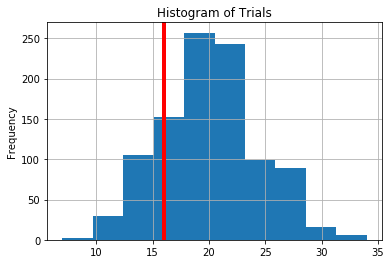

```python
trials_df = pd.DataFrame(trials, columns=['trial'])
pval =(trials_df['trial']<=16).sum()/float(n)
print("Estimated p-value: {0:.5f}".format(pval))
trials_df.hist()
plt.title("Histogram of Trials")
plt.ylabel("Frequency")
plt.axvline(x=16, color='r', linestyle='solid', lw=4)
plt.show()
```

Summary of Simulation Test Results:

- 16 or fewer returns are not unusual
- $𝑝$-value = 0.19
- Fail to Reject Null Hypothesis